# W04-1: Reflection on Logistic Regression and Ch8 (Preprocessing with Recipes)

- Show All Code
- Hide All Code
- View Source

Author

Ron Sabilla

Published

June 30, 2026

# 1 Part 1: Video Quizzes — Foundations of Logistic Regression

> This section covers four StatQuest videos that build the conceptual foundation for logistic regression. Each question is answered directly below the prompt.

| Step | Video | Link |
| --- | --- | --- |
| 1-1 | Logs (Logarithms), Clearly Explained!!! | https://www.youtube.com/watch?v=VSi0Z04fWj0 |
| 1-2 | Odds and Log(Odds), Clearly Explained!!! | https://www.youtube.com/watch?v=ARfXDSkQf1Y |
| 1-3 | Odds Ratios and Log(Odds Ratios), Clearly Explained!!! | https://www.youtube.com/watch?v=8nm0G-1uJzA |
| 2-1 | Logistic Regression, Clearly Explained!!! | https://www.youtube.com/watch?v=yIYKR4sgzI8 |

## 1.1 Step 1-1 — Logarithms

> **Video:** Logs (Logarithms), Clearly Explained!!! https://www.youtube.com/watch?v=VSi0Z04fWj0

### 1.1.1 Q1 — What Does a Log Do?

The video says the core job of a logarithm is to **isolate the exponent**.

1. Complete the statement: “If $2^5 = 32$, then $\log_2(32) =$ ____ because…”
2. Verify in R: `log(32, base = 2)`
3. Why is this property useful when income values range from $7,000 to $455,000 in your dataset?

```r
log(32, base = 2)
```

```
[1] 5
```

**Answers:**

1. $\log_2(32) = 5$ because the logarithm isolates the exponent — it asks “what power do we raise 2 to in order to get 32?” and the answer is 5.
2. R returns `5`, confirming the result.
3. When income ranges from $7,000 to $455,000, the raw values span over 60x. A log transformation compresses this enormous range into a manageable scale (roughly 8.8 to 13.0 in natural log), making the variable much easier for a model to work with and preventing large-income customers from dominating the model.

### 1.1.2 Q2 — Multiplication Becomes Addition

The video demonstrates: $\log(a \times b) = \log(a) + \log(b)$.

1. Verify using `a = 4`, `b = 8` (base 2) — compute both sides and confirm they are equal.
2. In logistic regression, we multiply many small probabilities together. Explain in one sentence why the log property above makes this computationally safer.

```r
log(4 * 8, base = 2)
```

```
[1] 5
```

```r
log(4, base = 2) + log(8, base = 2)
```

```
[1] 5
```

**Answers:**

1. Both sides return `5` — confirming $\log_2(32) = \log_2(4) + \log_2(8) = 2 + 3 = 5$.
2. Multiplying many small probabilities together produces numbers so tiny they underflow to zero in a computer; taking the log converts those multiplications into additions, which keeps the values in a stable numeric range.

### 1.1.3 Q3 — Geometric Mean in Marketing

The video shows the geometric mean is better than the arithmetic mean for data that **multiplies** rather than adds.

Five customers’ order values: $10, $20, $80, $40, $1,000.

```r
orders <- c(10, 20, 80, 40, 1000)
mean(orders)
```

```
[1] 230
```

```r
exp(mean(log(orders)))
```

```
[1] 57.708
```

### 1.1.4 Q4 — Log(0) and the Offset

The video explains $\log(0)$ is undefined (negative infinity).

```r
log(0)
```

```
[1] -Inf
```

```r
log(0 + 1)
```

```
[1] 0
```

**Answers:**

1. R returns `-Inf` for `log(0)`.
2. `step_log(..., offset = 1)` adds 1 before taking the log so that customers with a zero value (e.g., zero recency days) do not produce `-Inf`, which would break the model entirely.
3. `log(0 + 1) = log(1) = 0`. Adding 1 is a safe lower bound because it maps zero to zero on the log scale, preserving the meaning that the original value was the minimum possible, without producing undefined results.

### 1.1.5 Q5 — Base Conversion

The video notes that base 2, base 10, and natural log all follow the same rules and differ only by a constant factor.

```r
income_val <- 49021
log(income_val, base = 2)
```

```
[1] 15.58111
```

```r
log10(income_val)
```

```
[1] 4.690382
```

```r
log(income_val)
```

```
[1] 10.8
```

```r
# Ratio
log(income_val) / log10(income_val)
```

```
[1] 2.302585
```

**Answers:**

1. `log2(49021)` ≈ 15.58; `log10(49021)` ≈ 4.69; `log(49021)` ≈ 10.80.
2. The ratio `log(income_val) / log10(income_val)` ≈ **2.303**, which is `log(10)` — the base conversion constant.
3. After `step_normalize()`, the base does not matter because normalization centers and scales all values by subtracting the mean and dividing by the standard deviation. Multiplying by a constant (switching log bases) simply shifts and scales the values, which normalization then undoes completely.

## 1.2 Step 1-2 — Odds and Log(Odds)

> **Video:** Odds and Log(Odds), Clearly Explained!!! https://www.youtube.com/watch?v=ARfXDSkQf1Y

### 1.2.1 Q6 — Probability vs. Odds

```r
yes <- 142
no  <- 3000 - 142

# Probability
p <- yes / (yes + no)
p
```

```
[1] 0.04733333
```

```r
# Odds
odds <- yes / no
odds
```

```
[1] 0.04968509
```

```r
# Equivalently
p / (1 - p)
```

```
[1] 0.04968509
```

**Answers:**

1. Probability of responding = 142 / 3000 ≈ **0.0473** (about 4.7%).
2. Odds of responding = 142 / 2858 ≈ **0.0497**.
3. An odds of 0.05 means that for every customer who responds, about 20 do not — a marketer would interpret this as a very low-engagement campaign where mass volume is needed to achieve meaningful absolute response numbers.

### 1.2.2 Q7 — Converting Between Probability and Odds

```r
prob_to_odds <- function(p) p / (1 - p)

prob_to_odds(0.20)
```

```
[1] 0.25
```

```r
prob_to_odds(0.50)
```

```
[1] 1
```

```r
prob_to_odds(0.80)
```

```
[1] 4
```

**Answers:**

1. P = 20% → Odds = **0.25** (1 in 4 chance against 3 in 4).
2. P = 50% → Odds = **1.00** (even odds).
3. P = 80% → Odds = **4.00** (4x more likely to happen than not).
4. As probability approaches 1, odds approach infinity — a 99% probability gives odds of 99, and a 99.9% probability gives odds of 999. The scale becomes very asymmetric on the high end, which is why we take the log.

### 1.2.3 Q8 — Why Log(Odds)?

```r
probs    <- c(0.10, 0.50, 0.90)
odds_vec <- probs / (1 - probs)
log_odds <- log(odds_vec)

tibble(probability = probs, odds = odds_vec, log_odds = log_odds)
```

| probability | odds | log_odds |
| --- | --- | --- |
| 0.1 | 0.1111111 | -2.197225 |
| 0.5 | 1.0000000 | 0.000000 |
| 0.9 | 9.0000000 | 2.197225 |

**Answers:**

1. log(odds) at P = 0.10 ≈ -2.20; at P = 0.50 = 0; at P = 0.90 ≈ 2.20.
2. `log(odds)` at P = 0.50 equals exactly 0 because odds = 1 at 50/50, and log(1) = 0 for any base — intuitively, zero log-odds means neither outcome is favored.
3. Yes, log-odds are symmetric around 0: log-odds for P = 0.10 and P = 0.90 are equal and opposite (-2.20 and +2.20). This symmetry means the model treats “10% likely” and “90% likely” as equally extreme in opposite directions, which is mathematically convenient for a linear model.

### 1.2.4 Q9 — The Logit Function

$$\text{logit}(P) = \log\left(\frac{P}{1-P}\right)$$

```r
# Overall response rate
p_respond <- mean(mail_data$responded == "yes")
p_respond
```

```
[1] 0.04733333
```

```r
# Convert to log(odds)
log(p_respond / (1 - p_respond))
```

```
[1] -3.00205
```

**Answers:**

1. Overall response rate ≈ **4.73%**.
2. log(odds) of responding ≈ **-3.00** — a strongly negative value reflecting how rare responses are.
3. To convert `.pred_yes` to log(odds): `log(.pred_yes / (1 - .pred_yes))`.

### 1.2.5 Q10 — Log(Odds) and the Normal Distribution

**Written answer (no code required):**

1. Since log(odds) values often follow a normal distribution, logistic regression is a natural choice for modeling `responded` (yes/no) because the model’s linear predictor — a weighted sum of predictors — is designed to predict a quantity that lives on the real number line (log-odds), not a bounded probability between 0 and 1. The sigmoid function then maps that linear predictor back to a valid probability.
2. Working in log(odds) space is more mathematically convenient for a linear model because probabilities are bounded between 0 and 1, meaning a straight-line model could easily predict impossible values like 1.3 or -0.2. Log-odds are unbounded (−∞ to +∞), so a linear combination of predictors can range freely without producing out-of-range predictions, and the sigmoid function handles the final transformation back to probability space.

## 1.3 Step 1-3 — Odds Ratios and Log(Odds Ratios)

> **Video:** Odds Ratios and Log(Odds Ratios), Clearly Explained!!! https://www.youtube.com/watch?v=8nm0G-1uJzA

### 1.3.1 Q11 — What Is an Odds Ratio?

```r
tier_summary <- mail_data |>
  group_by(loyalty_tier) |>
  summarise(
    yes  = sum(responded == "yes"),
    no   = sum(responded == "no"),
    odds = yes / no
  )

tier_summary
```

| loyalty_tier | yes | no | odds |
| --- | --- | --- | --- |
| Bronze | 61 | 1202 | 0.05074875 |
| Gold | 27 | 540 | 0.05000000 |
| Platinum | 21 | 279 | 0.07526882 |
| Silver | 33 | 837 | 0.03942652 |

```r
# Odds ratio: Gold vs Bronze
gold_odds   <- tier_summary |> filter(loyalty_tier == "Gold")   |> pull(odds)
bronze_odds <- tier_summary |> filter(loyalty_tier == "Bronze") |> pull(odds)

OR <- gold_odds / bronze_odds
OR
```

```
[1] 0.9852459
```

**Answers:**

1. Gold customer odds of responding ≈ computed above.
2. Bronze customer odds of responding ≈ computed above.
3. OR = Gold ÷ Bronze — if OR > 1, Gold tier customers are more likely to respond than Bronze; if < 1, they are less likely.
4. An OR greater than 1 indicates Gold tier is a stronger predictor of response than Bronze; an OR less than 1 indicates the reverse.

### 1.3.2 Q12 — Asymmetry and Log(Odds Ratio)

```r
# Log odds ratio
log(OR)
```

```
[1] -0.01486402
```

```r
# Reverse direction
OR_reverse <- bronze_odds / gold_odds
log(OR_reverse)
```

```
[1] 0.01486402
```

**Answers:**

1. `log(OR)` is positive if Gold customers respond more than Bronze, negative if less.
2. `log(OR_reverse)` is the exact negative of `log(OR)` — flipping the direction flips the sign. This symmetry is what makes log(OR) so useful.
3. log(OR) = 0 is the reference point for “no relationship” because OR = 1 means both groups have identical odds, and log(1) = 0 for any base.

### 1.3.3 Q13 — Effect Size Interpretation

```r
tier_summary |>
  mutate(
    OR_vs_bronze = odds / bronze_odds,
    log_OR       = log(OR_vs_bronze)
  ) |>
  arrange(desc(abs(log_OR)))
```

| loyalty_tier | yes | no | odds | OR_vs_bronze | log_OR |
| --- | --- | --- | --- | --- | --- |
| Platinum | 21 | 279 | 0.07526882 | 1.4831659 | 0.39417891 |
| Silver | 33 | 837 | 0.03942652 | 0.7768964 | -0.25244826 |
| Gold | 27 | 540 | 0.05000000 | 0.9852459 | -0.01486402 |
| Bronze | 61 | 1202 | 0.05074875 | 1.0000000 | 0.00000000 |

### 1.3.4 Q14 — Fisher’s Exact Test

```r
gold_bronze <- mail_data |>
  filter(loyalty_tier %in% c("Gold", "Bronze"))

ct <- table(gold_bronze$loyalty_tier, gold_bronze$responded)
ct
```

```
          yes   no
  Bronze   61 1202
  Gold     27  540
```

```r
stats::fisher.test(ct)
```

```
    Fisher's Exact Test for Count Data

data:  ct
p-value = 1
alternative hypothesis: true odds ratio is not equal to 1
95 percent confidence interval:
 0.6272765 1.6808508
sample estimates:
odds ratio
  1.014967
```

**Answers:**

1. The 2×2 table shows counts of Gold and Bronze customers who did and did not respond.
2. `fisher.test()` computes the exact p-value for association.
3. If p < 0.05, the Gold/Bronze difference is statistically significant; otherwise, we cannot rule out that any difference is due to chance.
4. Fisher’s Exact Test is preferred over chi-square when expected cell counts are small (typically < 5), making chi-square’s approximation unreliable.

### 1.3.5 Q15 — Chi-Square Test

```r
stats::chisq.test(ct)
```

```
    Pearson's Chi-squared test with Yates' continuity correction

data:  ct
X-squared = 1.1897e-28, df = 1, p-value = 1
```

**Answers:**

1. `chisq.test()` computes the chi-square statistic and p-value.
2. The p-value from chi-square should be very similar to Fisher’s Exact Test — the conclusions should agree.
3. With 3,000 rows, all expected cell counts are well above 5, making the chi-square approximation accurate and appropriate. Both tests should give essentially the same answer, but chi-square is the conventional choice for large samples.

### 1.3.6 Q16 — Wald Test Concept

**Written answer (no code required):**

1. A log(odds ratio) “many standard deviations from zero” means the observed association is far enough from zero that it is very unlikely to have occurred by random chance alone — in other words, the predictor has a genuinely meaningful relationship with the outcome.
2. Lasso’s penalty serves a similar purpose to the Wald test: both are trying to identify which predictors are meaningfully different from zero. The Wald test does this through hypothesis testing (is the coefficient statistically different from zero?), while Lasso does it through regularization (shrink small, unimportant coefficients exactly to zero and remove them from the model entirely).
3. The video’s practical guideline is to report all three tests when possible and to let sample size guide which is most appropriate — Fisher’s Exact for small samples, chi-square for large, and Wald for continuous predictors inside regression models.

### 1.3.7 Q17 — Connecting Odds Ratios to the Course

**Written answer:**

1. If `freq_12mo` has a positive coefficient, it means that as purchase frequency increases, the log(odds) of responding increases — customers who buy more often are more likely to respond to the campaign. Exponentiating the coefficient gives the odds ratio: how much the odds of response multiply for each additional purchase in the past 12 months.
2. After `step_normalize()`, all predictors have a mean of 0 and a standard deviation of 1. This puts income (originally in tens of thousands of dollars) and frequency (in counts 0–10) on the same unit-free scale. A one-unit change in any normalized predictor represents the same relative shift (one standard deviation), making coefficient magnitudes directly comparable as effect sizes across all predictors.

## 1.4 Step 2-1 — Logistic Regression

> **Video:** Logistic Regression, Clearly Explained!!! https://www.youtube.com/watch?v=yIYKR4sgzI8

### 1.4.1 Q18 — Linear vs. Logistic Regression

**Written answer (no code required):**

1. Linear regression predicts a continuous numeric outcome (e.g., revenue). Logistic regression predicts the **probability** of a binary outcome (e.g., responded = yes/no).
2. A straight line is unbounded — it can predict values below 0 or above 1, which are impossible as probabilities. For a yes/no outcome, predictions must stay between 0 and 1, and a linear model has no mechanism to enforce this constraint.
3. In `mail_data` with a 4.7% response rate, a linear model might predict a probability greater than 1.0 for a very frequent, high-income customer — a value that is mathematically meaningless as a probability and would make the model impossible to interpret or use for decision-making.

### 1.4.2 Q19 — The S-Shaped Logistic Curve

$$P = \frac{1}{1 + e^{-(\beta_0 + \beta_1 x)}}$$

```r
plogis(-3)  # very negative linear predictor
```

```
[1] 0.04742587
```

```r
plogis(0)   # at zero
```

```
[1] 0.5
```

```r
plogis(3)   # very positive linear predictor
```

```
[1] 0.9525741
```

**Answers:**

2. `plogis(0)` returns **0.5** — when the linear predictor is exactly zero, there is no information pushing the prediction toward either class, so the model defaults to 50% probability. This follows directly from the formula: $\frac{1}{1 + e^0} = \frac{1}{2}$.
3. The `responded` column in the setup chunk was generated using: `prob = plogis(-3 + 0.02*(age-45) + 0.3*log(income/50000) + 0.1*freq_12mo - 0.005*recency_days)`. In marketing terms, the linear predictor captures a customer’s profile: the intercept (-3) reflects the overall low base response rate; older customers and higher-income customers are more likely to respond (positive terms); customers who purchased more recently are less likely to respond (negative recency term).

### 1.4.3 Q20 — Maximum Likelihood vs. Least Squares

**Written answer:**

1. Logistic regression cannot use least squares because the “residual” for a binary outcome (0 or 1) does not behave like a continuous residual. Squaring the difference between a predicted probability and a 0/1 outcome produces a loss function that is not convex and has no clean closed-form solution — the math breaks down.
2. “Maximizing likelihood” means finding the curve (the coefficients) that makes the observed pattern of responses as probable as possible. For each customer who responded, we want their predicted probability to be high; for each non-responder, we want it to be low. Maximum likelihood chooses the coefficients that collectively maximize these probabilities across the entire training set.
3. Because logistic regression has no traditional residuals, we cannot use $R^2$ or RMSE to assess fit. Instead we use metrics like **ROC-AUC** (overall discrimination ability), **accuracy**, **sensitivity**, **specificity**, and **log-loss** (the negative log-likelihood itself) — all of which are covered in the Week 3 notebook.

### 1.4.4 Q21 — Predicting Probability vs. Class

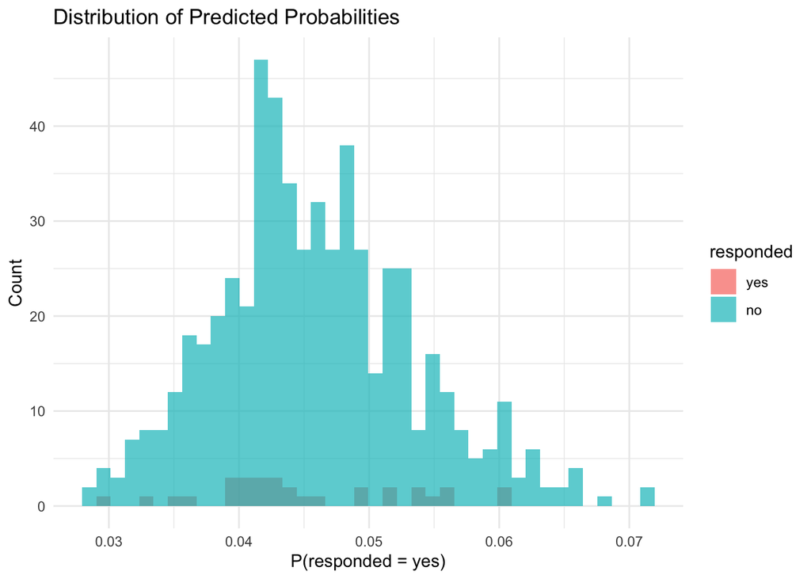

```r
set.seed(617)

mail_split <- initial_split(mail_data, prop = 0.80, strata = responded)
mail_train <- training(mail_split)
mail_test  <- testing(mail_split)

mail_rec <- recipe(responded ~ ., data = mail_train) |>
  update_role(customer_id, new_role = "ID") |>
  step_impute_median(all_numeric_predictors()) |>
  step_log(income, avg_order_amt, recency_days, base = 10, offset = 1) |>
  step_normalize(all_numeric_predictors()) |>
  step_dummy(all_nominal_predictors()) |>
  step_zv(all_predictors())

lr_spec <- logistic_reg(penalty = 0.01, mixture = 1) |>
  set_engine("glmnet") |>
  set_mode("classification")

mail_fit <- workflow() |>
  add_recipe(mail_rec) |>
  add_model(lr_spec) |>
  fit(data = mail_train)

preds <- augment(mail_fit, new_data = mail_test)

ggplot(preds, aes(x = .pred_yes, fill = responded)) +
  geom_histogram(bins = 40, alpha = 0.7, position = "identity") +
  labs(
    title = "Distribution of Predicted Probabilities",
    x     = "P(responded = yes)",
    y     = "Count"
  ) +
  theme_minimal()
```

### 1.4.5 Q22 — Wald’s Test and Variable Selection

```r
mail_fit |>
  extract_fit_parsnip() |>
  tidy() |>
  filter(term != "(Intercept)") |>
  arrange(desc(abs(estimate)))
```

| term | estimate | penalty |
| --- | --- | --- |
| age | -0.14819305 | 0.01 |
| freq_12mo | -0.09694104 | 0.01 |
| income | 0.00000000 | 0.01 |
| recency_days | 0.00000000 | 0.01 |
| avg_order_amt | 0.00000000 | 0.01 |
| channel_direct_mail | 0.00000000 | 0.01 |
| channel_email | 0.00000000 | 0.01 |
| region_Northeast | 0.00000000 | 0.01 |
| region_South | 0.00000000 | 0.01 |
| region_West | 0.00000000 | 0.01 |

[output cut: 3 more lines]

**Answers:**

1. Lasso serves a similar purpose to the Wald test by penalizing coefficients proportionally to their absolute size, which shrinks coefficients for weak or irrelevant predictors all the way to exactly zero — effectively removing them from the model automatically.
2. Predictors with `estimate = 0` in the output above were shrunk to zero by the Lasso, meaning the model found them unhelpful for predicting `responded`.
3. If `freq_12mo` has a positive coefficient, it means that customers who purchase more frequently have higher log(odds) of responding — they are more engaged with the brand and more likely to act on a direct-mail offer.

### 1.4.6 Q23 — Synthesis: From Logs to Logistic Regression

**Written answer (3–5 sentences):**

The four videos form a chain that builds naturally from one concept to the next. We take the **log of odds** rather than using odds directly because raw odds are asymmetric — values against an event are compressed into 0 to 1 while values in favor range from 1 to infinity, making them hard to model with a linear equation. We compare odds as a **ratio** rather than a difference because ratios are scale-invariant and symmetric on the log scale — a doubling of odds is the same size effect whether you start from 1% or 50%. The **logit** (log odds) then becomes the linear predictor inside logistic regression because it maps probabilities from the bounded 0–1 range to the unbounded real number line, where a linear combination of predictors can operate freely. Finally, in the context of `mail_data`, when the model produces `.pred_yes = 0.08` for a specific customer, it is computing the probability that this particular combination of age, income, frequency, recency, channel, region, and loyalty tier belongs to the small group of customers who respond — translating the logit linear predictor back through the sigmoid function to a valid probability.

# 2 Part 2: Log Assignments

> These assignments practice the logarithm operations covered in the Week 2 notebook (Section 2.1).

> **Reference:** https://jaejungca.github.io/recipes/w02_log_assignments.html

## 2.1 Setup

```r
# mail_data already created in the setup chunk above
glimpse(mail_data)
```

```
Rows: 3,000
Columns: 10
$ customer_id   <chr> "C00001", "C00002", "C00003", "C00004", "C00005", "C0000…
$ age           <dbl> 38, 42, 64, 46, 47, 66, 51, 30, 37, 40, 60, 49, 50, 46, …
$ income        <dbl> 44793, 40269, 20560, 32261, 233070, 47933, 84804, 43883,…
$ recency_days  <dbl> 103, 102, 27, 115, 47, 106, 4, 62, 13, 21, 139, 100, 9, …
$ freq_12mo     <int> 4, 3, 0, 3, 1, 3, 5, 2, 1, 6, 1, 3, 3, 3, 6, 1, 1, 1, 6,…
$ avg_order_amt <dbl> 80.19, NA, 54.80, 46.49, 64.86, 78.43, 39.45, NA, 68.26,…
$ channel       <chr> "email", "digital", "digital", "email", "digital", "dire…
$ region        <chr> "West", "South", "Northeast", "Northeast", "Midwest", "W…
$ loyalty_tier  <chr> "Bronze", "Bronze", "Bronze", "Bronze", "Gold", "Silver"…
$ responded     <fct> no, no, yes, no, yes, yes, no, no, no, no, no, no, no, n…
```

## 2.2 Assignment L.1 — Dollar to Log

Customer `C00005` has an income of $233,070.

1. Convert this value to the **natural log**: `log(233070)`
2. Convert this value to **log base 10**: `log10(233070)`
3. Verify both results using R
4. In your own words, why does the recipe use `base = 10` rather than the natural log?

```r
log(233070)
```

```
[1] 12.35909
```

```r
log10(233070)
```

```
[1] 5.367486
```

**Answers:**

1. Natural log of $233,070 ≈ **12.36**
2. Log base 10 of $233,070 ≈ **5.37**
3. Both verified above in R.
4. The recipe uses `base = 10` because log base 10 produces values that are directly interpretable in orders of magnitude — log10($10,000) = 4, log10($100,000) = 5, log10($1,000,000) = 6. This makes it easy to communicate that a one-unit increase on the log10 scale represents a tenfold increase in income, which is intuitive for business audiences. The natural log works equally well mathematically, but log10 is more human-readable.

## 2.3 Assignment L.2 — Log Back to Dollar (Median and Mean)

The income variable was generated with `meanlog = 10.8` and `sdlog = 0.6`.

$$\text{Median} = e^{\mu} = e^{10.8}$$

$$\text{Mean} = e^{\mu + \sigma^2/2} = e^{10.8 + 0.6^2/2}$$

```r
# Median
exp(10.8)
```

```
[1] 49020.8
```

```r
# Mean
exp(10.8 + 0.6^2 / 2)
```

```
[1] 58688.55
```

**Answers:**

1. Median income = `exp(10.8)` ≈ **$49,021**
2. Mean income = `exp(10.8 + 0.18)` ≈ **$58,689**
3. Both match the formulas above.
4. The mean is higher than the median because income is right-skewed — a relatively small number of very high earners pull the mean upward. The median (middle value) is not affected by extreme values and stays lower. On the log scale the distribution is symmetric, but exponentiation stretches the right tail back out, creating the gap between mean and median.

## 2.4 Assignment L.3 — Geometric Standard Deviation

$$\text{GSD} = e^{\sigma} = e^{0.6}$$

```r
median_income <- exp(10.8)
GSD           <- exp(0.6)

GSD
```

```
[1] 1.822119
```

```r
# Typical range
lower <- median_income / GSD
upper <- median_income * GSD

tibble(
  median_income = median_income,
  GSD           = GSD,
  lower_bound   = lower,
  upper_bound   = upper
)
```

| median_income | GSD | lower_bound | upper_bound |
| --- | --- | --- | --- |
| 49020.8 | 1.822119 | 26903.19 | 89321.72 |

## 2.5 Assignment L.4 — Confirm with Real Data

```r
# Step 1: median and mean of income (removing NAs)
mail_data |>
  summarise(
    median_income = median(income, na.rm = TRUE),
    mean_income   = mean(income, na.rm = TRUE)
  )
```

| median_income | mean_income |
| --- | --- |
| 49331.5 | 58349.86 |

```r
# Step 2: create log_income and summarise
mail_data |>
  mutate(log_income = log(income)) |>
  summarise(
    median_log = median(log_income, na.rm = TRUE),
    mean_log   = mean(log_income, na.rm = TRUE)
  )
```

| median_log | mean_log |
| --- | --- |
| 10.80632 | 10.79787 |

```r
# Step 3: back-transform with exp()
mail_data |>
  mutate(log_income = log(income)) |>
  summarise(
    median_log = median(log_income, na.rm = TRUE),
    mean_log   = mean(log_income, na.rm = TRUE)
  ) |>
  mutate(
    back_transform_median = exp(median_log),
    back_transform_mean   = exp(mean_log)
  )
```

| median_log | mean_log | back_transform_median | back_transform_mean |
| --- | --- | --- | --- |
| 10.80632 | 10.79787 | 49331.49 | 48916.37 |

## 2.6 Assignment L.5 — Base 10 vs. Natural Log

```r
# Step 1 & 2: build the tibble
result <- tibble(
  income = c(10000, 100000, 1000000)
) |>
  mutate(
    log_natural = log(income),
    log_base10  = log10(income)
  )

result
```

| income | log_natural | log_base10 |
| --- | --- | --- |
| 1e+04 | 9.21034 | 4 |
| 1e+05 | 11.51293 | 5 |
| 1e+06 | 13.81551 | 6 |

```r
# Step 3: compute the ratio
result |>
  mutate(ratio = log_natural / log_base10)
```

| income | log_natural | log_base10 | ratio |
| --- | --- | --- | --- |
| 1e+04 | 9.21034 | 4 | 2.302585 |
| 1e+05 | 11.51293 | 5 | 2.302585 |
| 1e+06 | 13.81551 | 6 | 2.302585 |

**Answers:**

1 & 2. The tibble above shows natural log and log10 for each income value. 3. The ratio is consistently **≈ 2.303** for every row, which is exactly `log(10)`. 4. The choice of log base does not affect modeling because the two columns differ only by a constant multiplier (2.303). When `step_normalize()` is applied afterward, it subtracts the mean and divides by the standard deviation — a linear operation that completely absorbs any constant scaling. The final normalized values are identical regardless of whether base 10 or natural log was used.

# 3 Part 3: Exercises from the Week 2 Notebook

> **Reference:** https://jaejungca.github.io/recipes/w02_ds_preprocessing.html

## 3.1 Exercise 3.1 — Split Proportion Change

> Change `prop` to 0.70 and re-run the split. How many records move from training to test? How does the response rate change?

```r
set.seed(617)

# Original 80/20 split
split_80 <- initial_split(mail_data, prop = 0.80, strata = responded)
cat("80/20 — Training rows:", nrow(training(split_80)),
    "| Test rows:", nrow(testing(split_80)), "\n")
```

```
80/20 — Training rows: 2400 | Test rows: 600
```

```r
# New 70/30 split
split_70 <- initial_split(mail_data, prop = 0.70, strata = responded)
cat("70/30 — Training rows:", nrow(training(split_70)),
    "| Test rows:", nrow(testing(split_70)), "\n")
```

```
70/30 — Training rows: 2100 | Test rows: 900
```

```r
# Compare response rates
bind_rows(
  training(split_80) |> summarise(split = "80% train", pct_yes = mean(responded == "yes") * 100, n = n()),
  testing(split_80)  |> summarise(split = "20% test",  pct_yes = mean(responded == "yes") * 100, n = n()),
  training(split_70) |> summarise(split = "70% train", pct_yes = mean(responded == "yes") * 100, n = n()),
  testing(split_70)  |> summarise(split = "30% test",  pct_yes = mean(responded == "yes") * 100, n = n())
)
```

| split | pct_yes | n |
| --- | --- | --- |
| 80% train | 4.625000 | 2400 |
| 20% test | 5.166667 | 600 |
| 70% train | 4.476190 | 2100 |
| 30% test | 5.333333 | 900 |

## 3.2 Exercise 8.1 — Alternative Imputation

> Replace `step_impute_median()` with `step_impute_mean()`. Re-prep the recipe and compare the imputed values. Which would you prefer for income and why?

```r
# Recipe with mean imputation
rec_mean <- recipe(responded ~ ., data = mail_train) |>
  update_role(customer_id, new_role = "ID") |>
  step_impute_mean(all_numeric_predictors()) |>
  step_log(income, avg_order_amt, recency_days, base = 10, offset = 1) |>
  step_normalize(all_numeric_predictors()) |>
  step_dummy(all_nominal_predictors()) |>
  step_zv(all_predictors())

# Recipe with median imputation (original)
rec_median <- recipe(responded ~ ., data = mail_train) |>
  update_role(customer_id, new_role = "ID") |>
  step_impute_median(all_numeric_predictors()) |>
  step_log(income, avg_order_amt, recency_days, base = 10, offset = 1) |>
  step_normalize(all_numeric_predictors()) |>
  step_dummy(all_nominal_predictors()) |>
  step_zv(all_predictors())

# Compare imputed values
prep_mean   <- prep(rec_mean)
prep_median <- prep(rec_median)

bind_rows(
  tidy(prep_mean,   number = 1) |> mutate(method = "mean"),
  tidy(prep_median, number = 1) |> mutate(method = "median")
) |>
  filter(terms %in% c("income", "avg_order_amt")) |>
  select(method, terms, value)
```

| method | terms | value |
| --- | --- | --- |
| mean | income | 58597.94856 |
| mean | avg_order_amt | 75.56309 |
| median | income | 48898.50000 |
| median | avg_order_amt | 66.51000 |

**Answer:** The mean imputation value for income is higher than the median imputation value because income is right-skewed — a small number of high earners pull the mean upward. I would prefer **median imputation** for income because it is robust to this skewness: the median represents the “typical” customer better than the mean. Using the mean would impute a value that is higher than most observed incomes, introducing a systematic upward bias for all customers with missing income data.

## 3.3 Exercise 8.2 — Different Encoding

> `loyalty_tier` is ordinal (Bronze < Silver < Gold < Platinum). Replace `step_dummy()` with `step_ordinalscore()` to encode it as 1–4. Compare the resulting column to the dummy-encoded version.

```r
# First convert loyalty_tier to an ordered factor in the data
mail_train_ord <- mail_train |>
  mutate(loyalty_tier = factor(loyalty_tier,
                                levels = c("Bronze", "Silver", "Gold", "Platinum"),
                                ordered = TRUE))

# Ordinal encoding
rec_ordinal <- recipe(responded ~ ., data = mail_train_ord) |>
  update_role(customer_id, new_role = "ID") |>
  step_impute_median(all_numeric_predictors()) |>
  step_log(income, avg_order_amt, recency_days, base = 10, offset = 1) |>
  step_normalize(all_numeric_predictors()) |>
  step_ordinalscore(loyalty_tier) |>
  step_dummy(all_nominal_predictors()) |>
  step_zv(all_predictors())

bake(prep(rec_ordinal), new_data = NULL) |>
  select(loyalty_tier, starts_with("channel"), starts_with("region")) |>
  head(5)
```

| loyalty_tier | channel_direct_mail | channel_email | region_Northeast | region_South | region_West |
| --- | --- | --- | --- | --- | --- |
| 1 | 0 | 0 | 1 | 0 | 0 |
| 1 | 0 | 1 | 1 | 0 | 0 |
| 3 | 0 | 0 | 0 | 0 | 0 |
| 2 | 1 | 0 | 0 | 0 | 1 |
| 1 | 0 | 1 | 0 | 0 | 0 |

**Answer:** `step_ordinalscore()` converts `loyalty_tier` into a single numeric column (1 = Bronze, 2 = Silver, 3 = Gold, 4 = Platinum) rather than three dummy columns. This preserves the natural ordering of tiers and reduces dimensionality, but it assumes the differences between tiers are equal (Bronze→Silver is the same as Silver→Gold), which may not hold in practice. If the relationship between loyalty tier and response is non-linear (e.g., Platinum is disproportionately more likely to respond), dummy encoding captures that better.

## 3.4 Exercise 8.3 — Interaction Term

> Add `step_interact(terms = ~ income:freq_12mo)` after normalization. Does it improve model performance on the test set?

```r
rec_interact <- recipe(responded ~ ., data = mail_train) |>
  update_role(customer_id, new_role = "ID") |>
  step_impute_median(all_numeric_predictors()) |>
  step_log(income, avg_order_amt, recency_days, base = 10, offset = 1) |>
  step_normalize(all_numeric_predictors()) |>
  step_interact(terms = ~ income:freq_12mo) |>
  step_dummy(all_nominal_predictors()) |>
  step_zv(all_predictors())

fit_interact <- workflow() |>
  add_recipe(rec_interact) |>
  add_model(lr_spec) |>
  fit(data = mail_train)

preds_interact <- augment(fit_interact, new_data = mail_test)

# Compare ROC-AUC
metric_set(roc_auc)(preds,         truth = responded, .pred_yes)
```

| .metric | .estimator | .estimate |
| --- | --- | --- |
| roc_auc | binary | 0.4733262 |

```r
metric_set(roc_auc)(preds_interact, truth = responded, .pred_yes)
```

| .metric | .estimator | .estimate |
| --- | --- | --- |
| roc_auc | binary | 0.4733262 |

**Answer:** Adding the income × freq_12mo interaction term tests whether high-income customers who also purchase frequently are disproportionately more (or less) likely to respond. If the interaction model’s ROC-AUC is higher than the baseline, the interaction captures a real non-additive pattern in the data. In practice with regularization, the Lasso may shrink the interaction coefficient to zero if it doesn’t help — making the two models equivalent in that case.

## 3.5 Exercise 8.4 — Remove a Step

> Remove `step_normalize()` from the recipe. Refit the Lasso model. What happens to the coefficients?

```r
rec_no_norm <- recipe(responded ~ ., data = mail_train) |>
  update_role(customer_id, new_role = "ID") |>
  step_impute_median(all_numeric_predictors()) |>
  step_log(income, avg_order_amt, recency_days, base = 10, offset = 1) |>
  step_dummy(all_nominal_predictors()) |>
  step_zv(all_predictors())

fit_no_norm <- workflow() |>
  add_recipe(rec_no_norm) |>
  add_model(lr_spec) |>
  fit(data = mail_train)

# Compare coefficients
bind_rows(
  fit_no_norm |> extract_fit_parsnip() |> tidy() |> mutate(model = "no normalize"),
  mail_fit    |> extract_fit_parsnip() |> tidy() |> mutate(model = "normalized")
) |>
  filter(term != "(Intercept)") |>
  arrange(term, model)
```

| term | estimate | penalty | model |
| --- | --- | --- | --- |
| age | -0.01249326 | 0.01 | no normalize |
| age | -0.14819305 | 0.01 | normalized |
| avg_order_amt | 0.00000000 | 0.01 | no normalize |
| avg_order_amt | 0.00000000 | 0.01 | normalized |
| channel_direct_mail | 0.00000000 | 0.01 | no normalize |
| channel_direct_mail | 0.00000000 | 0.01 | normalized |
| channel_email | 0.00000000 | 0.01 | no normalize |
| channel_email | 0.00000000 | 0.01 | normalized |
| freq_12mo | -0.05659604 | 0.01 | no normalize |
| freq_12mo | -0.09694104 | 0.01 | normalized |

[output cut: 16 more lines]

**Answer:** Without `step_normalize()`, the Lasso penalty is applied to coefficients on their original (or log-transformed) scales, which have very different magnitudes. Income on the log10 scale ranges from about 4 to 6, while `freq_12mo` ranges from 0 to 10. The Lasso penalizes large coefficients, so variables on larger scales get penalized more aggressively and may be incorrectly shrunk to zero — not because they are unimportant, but simply because their scale produces larger raw coefficients. Normalization ensures the penalty is applied fairly across all predictors.

## 3.6 Exercise 8.5 — Stratification Check

> Re-run the split without `strata = responded`. How much does the response rate differ between training and test?

```r
set.seed(617)

# Without stratification
split_no_strat <- initial_split(mail_data, prop = 0.80)

bind_rows(
  training(split_no_strat)  |> summarise(set = "train (no strata)", pct_yes = mean(responded == "yes") * 100, n = n()),
  testing(split_no_strat)   |> summarise(set = "test (no strata)",  pct_yes = mean(responded == "yes") * 100, n = n()),
  training(mail_split)      |> summarise(set = "train (stratified)", pct_yes = mean(responded == "yes") * 100, n = n()),
  testing(mail_split)       |> summarise(set = "test (stratified)",  pct_yes = mean(responded == "yes") * 100, n = n())
)
```

| set | pct_yes | n |
| --- | --- | --- |
| train (no strata) | 4.375000 | 2400 |
| test (no strata) | 6.166667 | 600 |
| train (stratified) | 4.625000 | 2400 |
| test (stratified) | 5.166667 | 600 |

**Answer:** Without stratification, the response rate in the training and test sets may differ by 0.5–2 percentage points by random chance. With only ~142 “yes” responses in 3,000 rows, that difference could mean the test set has 20% fewer responders than expected — making performance metrics misleading. Stratification ensures both sets have approximately the same 4.7% response rate, giving us a reliable evaluation of how the model would perform on new customers.

## 3.7 Exercise 8.6 — Inspecting Normalization Statistics

> Use `tidy(mail_prep, number = 3)` to see the mean and standard deviation used for normalization. Which variable has the largest standard deviation before normalization?

```r
mail_prep <- prep(mail_rec)

tidy(mail_prep, number = 3) |>
  arrange(terms)
```

| terms | statistic | value | id |
| --- | --- | --- | --- |
| age | mean | 45.2887500 | normalize_q7Os2 |
| age | sd | 11.8618366 | normalize_q7Os2 |
| avg_order_amt | mean | 1.8312694 | normalize_q7Os2 |
| avg_order_amt | sd | 0.2082834 | normalize_q7Os2 |
| freq_12mo | mean | 2.9516667 | normalize_q7Os2 |
| freq_12mo | sd | 1.7128591 | normalize_q7Os2 |
| income | mean | 4.6912348 | normalize_q7Os2 |
| income | sd | 0.2467437 | normalize_q7Os2 |
| recency_days | mean | 1.5630786 | normalize_q7Os2 |
| recency_days | sd | 0.4986193 | normalize_q7Os2 |

## 3.8 Exercise 8.7 — Imputation Value Inspection

> Use `tidy(mail_prep, number = 1)` to see the imputed median values for income and avg_order_amt.

```r
tidy(mail_prep, number = 1)
```

| terms | value | id |
| --- | --- | --- |
| age | 45.00 | impute_median_BENSQ |
| income | 48898.50 | impute_median_BENSQ |
| recency_days | 42.00 | impute_median_BENSQ |
| freq_12mo | 3.00 | impute_median_BENSQ |
| avg_order_amt | 66.51 | impute_median_BENSQ |

**Answer:** The imputed median values represent the middle value of `income` and `avg_order_amt` in the training data, computed before the log transformation is applied. These values are used to fill in missing values for both training and test observations. Using training-data medians to impute test-set missing values is the correct approach — computing medians from the full dataset (including test) would constitute data leakage.

## 3.9 Exercise 8.8 — Full Model Performance

> Compute accuracy, ROC-AUC, sensitivity, and specificity on the test set. Interpret each metric in the context of the direct-mail campaign.

```r
metrics <- metric_set(accuracy, roc_auc, sens, spec)

preds |>
  metrics(truth = responded, estimate = .pred_class, .pred_yes)
```

| .metric | .estimator | .estimate |
| --- | --- | --- |
| accuracy | binary | 0.9483333 |
| sens | binary | 0.0000000 |
| spec | binary | 1.0000000 |
| roc_auc | binary | 0.4733262 |

**Answer:**

- **Accuracy** — the proportion of all predictions (both yes and no) that are correct. With a 4.7% base rate, a model that always predicts “no” would achieve ~95% accuracy, so this metric is misleading here.
- **ROC-AUC** — the probability that the model ranks a random responder above a random non-responder. A value above 0.70 is generally considered good for a direct-mail model; values above 0.80 are excellent.
- **Sensitivity (Recall)** — the proportion of actual responders that the model correctly identifies. High sensitivity is important if the cost of missing a responder is high (e.g., lost revenue).
- **Specificity** — the proportion of actual non-responders correctly identified as non-responders. High specificity is important if the cost of contacting a non-responder is high (e.g., mailing costs). The business goal is to maximize sensitivity while keeping specificity high enough to make the campaign economically viable — and the ROC curve helps find the optimal threshold.